# SFS

Claudius

21/12/2016

I have run `realSFS` with a *tolerance* (`-tole`) of 1e-6, which means that the EM iteration is stopped if the likelihoods of the last two iterations differed by less than 1e-6. I specified a maximum number of EM iterations of 50000 (`-maxIter`) after examining the speed at which both ERY and PAR reach the *tolerance* stopping criterium. I have also turned off the accelerated EM algorithm with `-m 0`. This guarantees that a good ML estimate of the SFS is found, but much more slowly. The ML estimate of the folded SFS in ERY is found within 8 minutes, the one of PAR within 26 minutes.

```r
ery.sfs = scan("ERY/ERY.FOLDED.sfs")
par.sfs = scan("PAR/PAR.FOLDED.sfs")
ery.sfs = ery.sfs[-1]
par.sfs = par.sfs[-1]
```

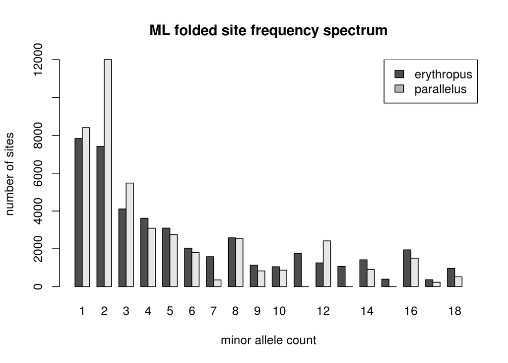

```r
barplot(rbind(ery.sfs, par.sfs),
        names.arg=1:length(ery.sfs),
        beside=TRUE,
        xlab="minor allele count",
        ylab="number of sites",
        main="ML folded site frequency spectrum"
        )
legend("topright",
        legend=c("erythropus", "parallelus"),
        fill=c(gray(.3), gray(.7))
        )
```

I have rerun the exhaustive ML search from above:

```r
ery.sfs1 = scan("ERY/ERY.FOLDED.sfs1")
par.sfs1 = scan("PAR/PAR.FOLDED.sfs1")
ery.sfs1 = ery.sfs1[-1]
par.sfs1 = par.sfs1[-1]
```

## Variability in the ML estimate of folded SFS

I have repeated the ML estimation of per-population folded SFS with `realSFS` 100 times. Other than specifying the number of threads, I left all other parameters for `realSFS` at the default. These default values are not documented. With the accelerated EM algorithm (turned on by default), `realSFS` reaches a ML estimate very fast (<1min).

```r
ery.SFS.repeated = read.table("ERY/ERY.FOLDED.sfs.ml", header=F)
par.SFS.repeated = read.table("PAR/PAR.FOLDED.sfs.ml", header=F)
```

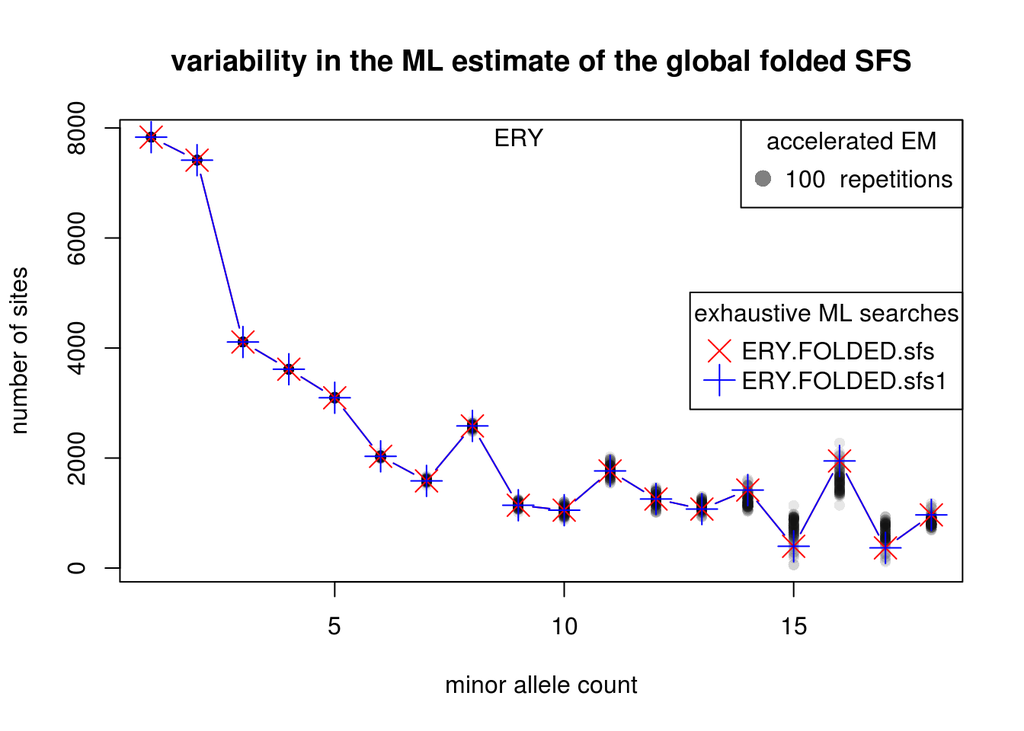

```r
matplot(1:18,
        t(ery.SFS.repeated[,2:length(ery.SFS.repeated)]),
        #type="l",
        #lty=1,
        pch=16,
        col=gray(.1, alpha=.1),
        ylab="number of sites",
        xlab="minor allele count",
        main="variability in the ML estimate of the global folded SFS"
        )
# add the first exhaustive ML SFS:
points(1:18, ery.sfs, pch=4, cex=2, col="red", type="b")
# add the second exhaustive ML SFS:
points(1:18, ery.sfs1, pch=3, cex=2, col="blue", type="b")
#text(15, 6000, labels=paste(nrow(ery.SFS.repeated), " repetitions"))
text(9, max(ery.sfs), labels="ERY")
legend("right", legend=c("ERY.FOLDED.sfs", "ERY.FOLDED.sfs1"), title="exhaustive ML searches", pch=c(4,3), pt.cex=2, col=c("red", "blue"))
legend("topright", legend=paste(nrow(ery.SFS.repeated), " repetitions"), title="accelerated EM", pch=16, pt.cex=1.5, col=gray(.5))
```

The EM algorithm doesn’t seem to be converging well for the minor allele count categories 10 onwards. However, the two exhaustive EM searches are matching perfectly. So, I assume they have converged.

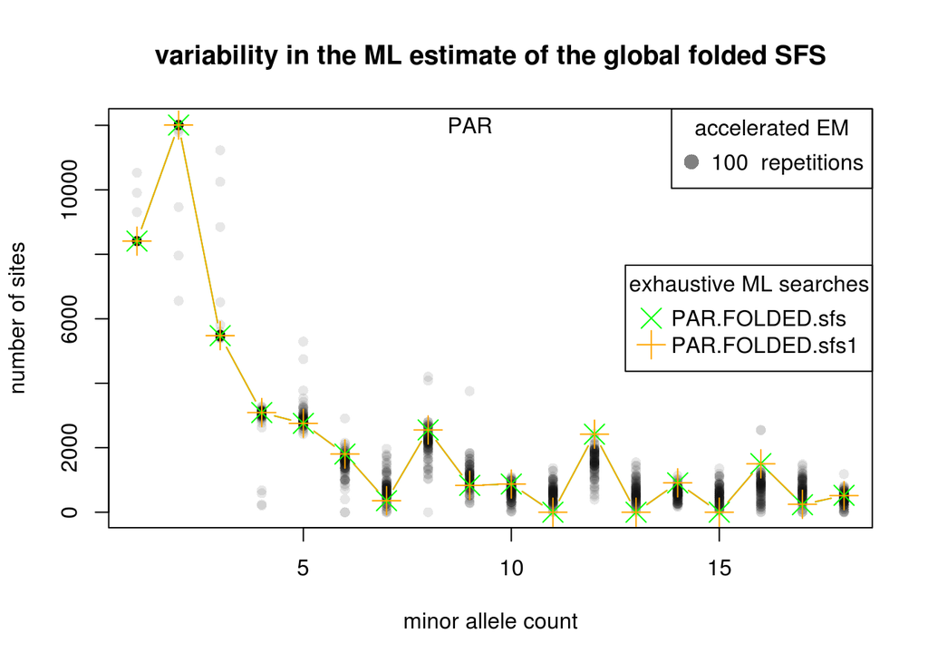

```r
matplot(1:18,
        t(par.SFS.repeated[,2:length(par.SFS.repeated)]),
        #type="l",
        #lty=1,
        pch=16,
        col=gray(.1, alpha=.1),
        ylab="number of sites",
        xlab="minor allele count",
        main="variability in the ML estimate of the global folded SFS"
        )
points(1:18, par.sfs, pch=4, cex=2, col="green", type="b")
points(1:18, par.sfs1, pch=3, cex=2, col="orange", type="b")
#text(15, 10000, labels=paste(nrow(par.SFS.repeated), " repetitions"))
text(9, max(par.sfs), labels="PAR")
legend("topright", legend=paste(nrow(par.SFS.repeated), " repetitions"), pch=16, pt.cex=1.5, col=gray(.5), title="accelerated EM")
legend("right", legend=c("PAR.FOLDED.sfs", "PAR.FOLDED.sfs1"), pch=c(4, 3), pt.cex=2, col=c("green", "orange"), title="exhaustive ML searches")
```

The EM algorithm doesn’t seem to be able to resolve the *parallelus* SFS very well. There is a clear lack of convergence. However, the two exhaustive searches are matching perfectly. So I assume that they have converged.

## Bootstrapping the ML estimate of SFS

I have run 1000 bootstrap resamples of the ML SFS with `realSFS`. That should mean that sites are resampled with replacement. I have run `realSFS` with default parameters, i. e. accelerated EM algorithm and no specification of *tolerance*. That means that the bootstrap resampled SFS’s also comprise the variability from the non-convergent EM algorithm.

```r
ery.sfs.boot = read.table("ERY/ERY.FOLDED.sfs.boot", header=F)
dim(ery.sfs.boot)
```

```
## [1] 1000   19
```

```r
head(ery.sfs.boot)
```

```
##        V1       V2       V3       V4       V5       V6       V7       V8
## 1 1594879 7903.243 7234.055 4136.505 3838.378 2707.879 1992.625 1697.601
## 2 1594699 7909.674 7529.947 4081.698 3620.874 2879.184 2246.444 1313.428
## 3 1595126 7946.673 7129.572 4188.539 3744.500 2948.531 2303.541 1012.977
## 4 1594956 7741.281 7550.142 4031.951 3595.505 3404.369 1115.118 1988.408
## 5 1594886 7837.500 7406.485 4404.702 3017.601 3632.463 1848.845 1230.987
## 6 1595165 7515.667 7709.521 4031.582 3478.765 3275.150 1953.804 1378.622
##         V9      V10       V11      V12       V13       V14        V15
## 1 2478.382 1271.848 1385.3118 1176.088 1418.0754  976.7206 2114.65273
## 2 2790.336 1132.065 1289.2601 1610.352 1387.3182  962.5968 1297.96773
## 3 2742.193 1331.571  819.8329 2094.930  937.1667 1207.5922 1215.28343
## 4 2709.146 1180.064  844.0100 1880.201 1464.0577  932.9834 1093.36706
## 5 3115.726 1085.532  538.3746 2091.975 1450.3488 1316.7758   83.99772
## 6 2500.747 1295.607 1199.1880 1592.713 1289.0190  973.8882 1207.27658
##           V16       V17       V18       V19
## 1    2.213088 1278.8277 1413.1249  563.6436
## 2  647.181814 1504.1238  459.4593 1107.1159
## 3  590.165772 1841.3445  622.9443  664.6468
## 4  933.897642 1567.1196  249.5184 1231.0616
## 5 2185.984806  756.3558  677.2863  901.2564
## 6  897.190543 1369.5888  940.1851  694.0233
```

```r
ery.sfs.boot = ery.sfs.boot[,2:ncol(ery.sfs.boot)]
#
par.sfs.boot = read.table("PAR/PAR.FOLDED.sfs.boot", header=F)
dim(par.sfs.boot)
```

```
## [1] 1000   19
```

```r
head(par.sfs.boot)
```

```
##        V1       V2       V3       V4       V5       V6       V7        V8
## 1 1171324 8201.846 12025.73 5661.360 2925.310 2752.701 1535.023 1352.4547
## 2 1171060 8336.056 12414.55 5003.499 3387.871 2683.957 1402.626  410.7145
## 3 1170931 8206.609 12389.25 5031.972 3411.987 2538.000 1988.841 1063.9384
## 4 1171132 8815.809 11682.66 5726.325 2832.267 3063.915 1620.235  510.5651
## 5 1171206 8576.130 12062.33 4758.590 3345.753 3169.881 1015.630 1201.5162
## 6 1171165 8389.585 12018.78 5417.129 2616.547 3514.318 1081.157 1441.5987
##         V9       V10       V11       V12      V13       V14      V15
## 1 1305.307 1681.0654  208.2181 321.30461 2640.092 270.97545 154.8678
## 2 3427.989  273.6585  470.2010 385.08065 2225.303 358.36897 505.6179
## 3 1875.075  789.1736 1278.7714  64.45086 2037.173 646.01243 399.9172
## 4 2699.043  277.9489  833.9820 637.38651 1704.831 642.35583 144.8005
## 5 1794.597 1721.8902  398.2425 361.78698 1941.335 352.49832 242.8081
## 6 1047.644 2123.5240  523.6656 211.29591 2233.669  12.44522 583.1325
##         V16        V17        V18      V19
## 1  664.9437 1059.78363  289.41756 565.0780
## 2 1151.9823  393.69157  300.19101 747.6168
## 3  190.9907 1517.38099   25.55789 552.9194
## 4 1031.2852   80.15652 1222.26208 281.1951
## 5  847.7157 1357.59866  263.39550 320.8438
## 6 1030.5399  157.61871  558.79513 812.6591
```

```r
par.sfs.boot = par.sfs.boot[,2:ncol(par.sfs.boot)]
```

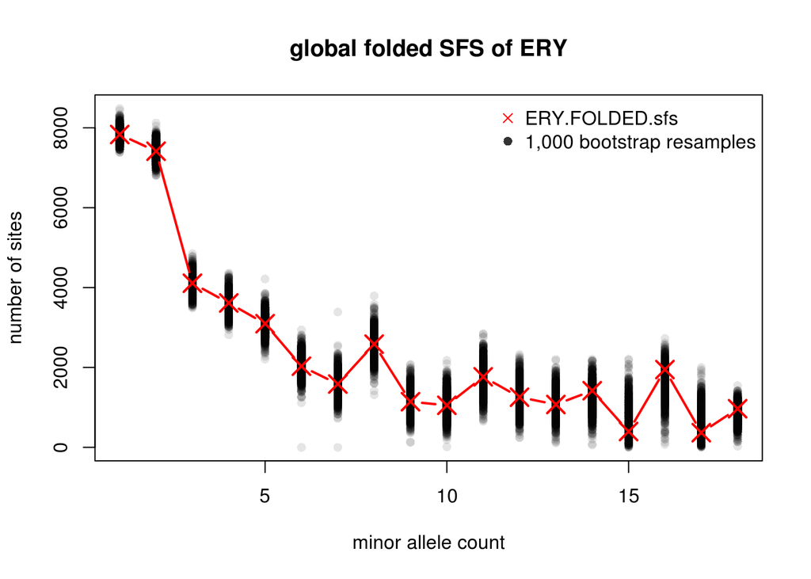

```r
matplot(1:18,
        t(ery.sfs.boot),
        #type="l",
        #lty=1,
        pch=16,
        col=gray(0, alpha=.1),
        ylab="number of sites",
        xlab="minor allele count",
        main="global folded SFS of ERY"
        )
# adding the real sample ML estimate to the plot:
points(1:18, ery.sfs, pch=4, cex=2, col="red", type="b", lwd=2)
#text(15, 6000, labels=paste(nrow(ery.SFS.repeated), " repetitions"))
legend("topright",
       legend=c("ERY.FOLDED.sfs", "1,000 bootstrap resamples"),
       pch=c(4,16),
       pt.cex=1,
       col=c("red", gray(.2, alpha=1)),
       bty="n"
       )
```

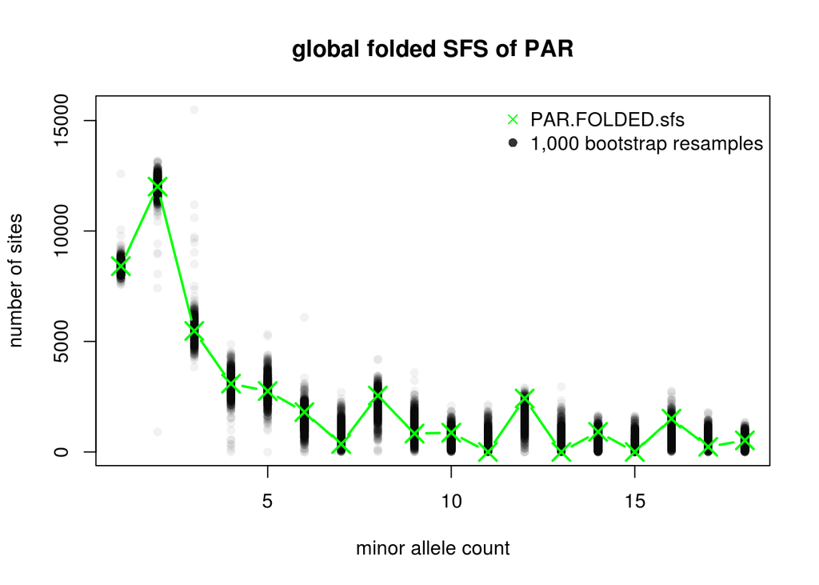

```r
matplot(1:18,
        t(par.sfs.boot),
        #type="l",
        #lty=1,
        pch=16,
        col=gray(0, alpha=.05),
        ylab="number of sites",
        xlab="minor allele count",
        main="global folded SFS of PAR"
        )
# adding the real sample ML estimate to the plot:
points(1:18, par.sfs, pch=4, cex=2, col="green", type="b", lwd=2)
#text(15, 6000, labels=paste(nrow(ery.SFS.repeated), " repetitions"))
legend("topright",
       legend=c("PAR.FOLDED.sfs", "1,000 bootstrap resamples"),
       pch=c(4,16),
       pt.cex=1,
       col=c("green", gray(.2, alpha=1)),
       bty="n"
       )
```

```r
ery.sfs.CI95 = data.frame(
  low=vector("double", ncol(ery.sfs.boot)),
  med=vector("double", ncol(ery.sfs.boot)),
  high=vector("double", ncol(ery.sfs.boot))
  )
#
for(i in 1:ncol(ery.sfs.boot)){
  ery.sfs.CI95[i,] = quantile(ery.sfs.boot[,i], probs=c(0.25, 0.5, 0.975))
}
#
par.sfs.CI95 = data.frame(
  low=vector("double", ncol(par.sfs.boot)),
  med=vector("double", ncol(par.sfs.boot)),
  high=vector("double", ncol(par.sfs.boot))
  )
#
for(i in 1:ncol(par.sfs.boot)){
  par.sfs.CI95[i,] = quantile(par.sfs.boot[,i], probs=c(0.25, 0.5, 0.975))
}
```

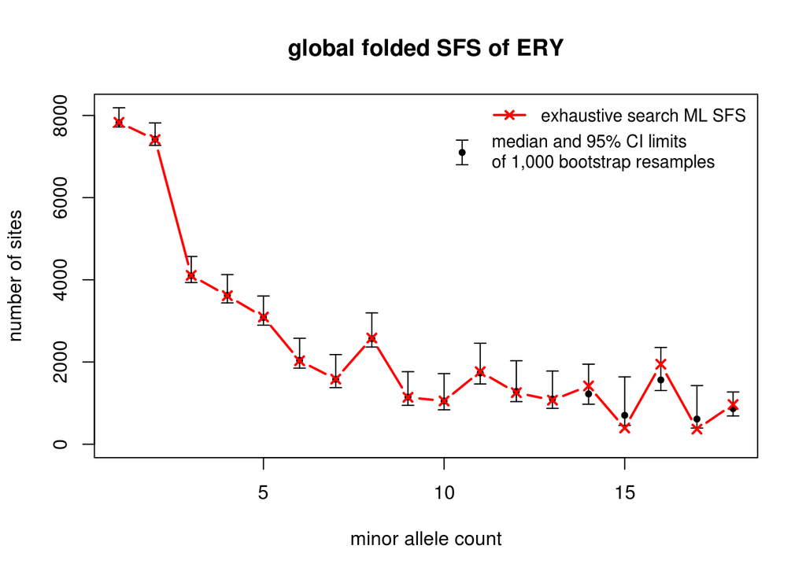

```r
plot(1:nrow(ery.sfs.CI95), ery.sfs.CI95$med,
     ylim=c(0, max(ery.sfs.CI95)),
     pch=20,
     xlab="minor allele count",
     ylab="number of sites",
     main="global folded SFS of ERY"
     )
arrows(1:nrow(ery.sfs.CI95), ery.sfs.CI95$med,
       1:nrow(ery.sfs.CI95), ery.sfs.CI95$high,
       angle=90,
       length=.05
       )
arrows(1:nrow(ery.sfs.CI95), ery.sfs.CI95$med,
       1:nrow(ery.sfs.CI95), ery.sfs.CI95$low,
       angle=90,
       length=.05
       )
points(1:18, ery.sfs, pch=4, cex=1, col="red", type="b", lwd=2)
legend("topright", legend="exhaustive search ML SFS", bty="n", col="red", pch=4, lwd=2, cex=.9)
#
points(10.5, 7100, pch=20)
arrows(10.5, 7100,
       10.5, 7400,
       angle=90,
       length=.05
       )
arrows(10.5, 7100,
       10.5, 6800,
       angle=90,
       length=.05
       )
#
text(11, 7000,
     labels="median and 95% CI limits\nof 1,000 bootstrap resamples",
     cex=.9, pos=4)
```

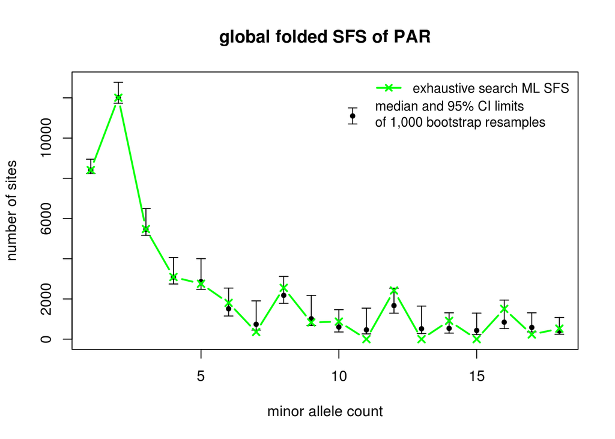

```r
plot(1:nrow(par.sfs.CI95), par.sfs.CI95$med,
     ylim=c(0, max(par.sfs.CI95)),
     pch=20,
     xlab="minor allele count",
     ylab="number of sites",
     main="global folded SFS of PAR"
     )
arrows(1:nrow(par.sfs.CI95), par.sfs.CI95$med,
       1:nrow(par.sfs.CI95), par.sfs.CI95$high,
       angle=90,
       length=.05
       )
arrows(1:nrow(par.sfs.CI95), par.sfs.CI95$med,
       1:nrow(par.sfs.CI95), par.sfs.CI95$low,
       angle=90,
       length=.05
       )
points(1:18, par.sfs, pch=4, cex=1, col="green", type="b", lwd=2)
legend("topright", legend="exhaustive search ML SFS", bty="n", col="green", pch=4, lwd=2, cex=.9)
#
points(10.5, 11100, pch=20)
arrows(10.5, 11100,
       10.5, 11500,
       angle=90,
       length=.05
       )
arrows(10.5, 11100,
       10.5, 10700,
       angle=90,
       length=.05
       )
#
text(11, 11000,
     labels="median and 95% CI limits\nof 1,000 bootstrap resamples",
     cex=.9, pos=4)
```

Several frequency classes (11, 13, 15) have exhaustive search ML estimates outside the 95% CI from the 1000 bootstrap resamples that were run with accelerated EM. I wonder whether the exhaustive search ML SFS is significant or whether it is maximising the likelihood of insignificant noise in the data due to a lack of information in the higher count classes.

## Bootstraps with exhaustive ML search

```r
ery.sfs.boot.exh = read.table("ERY/ERY.FOLDED.sfs.boot.exh", header=F)
dim(ery.sfs.boot.exh)
```

```
## [1] 200  19
```

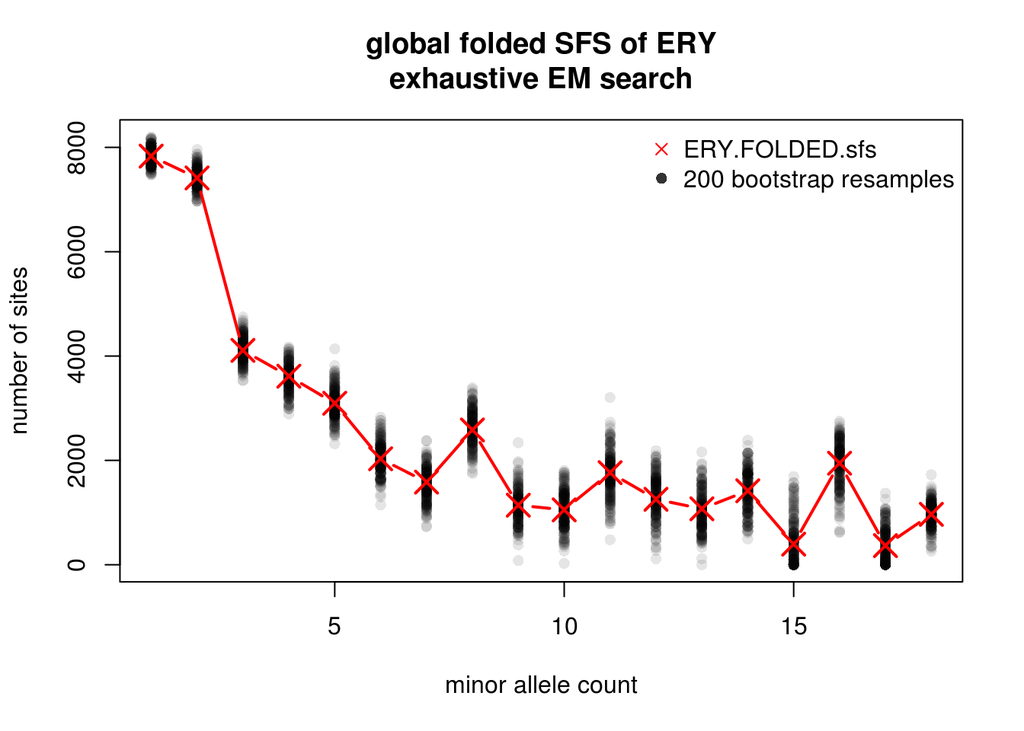

```r
matplot(1:18,
        t(ery.sfs.boot.exh[2:ncol(ery.sfs.boot.exh)]),
        #type="l",
        #lty=1,
        pch=16,
        col=gray(0, alpha=.1),
        ylab="number of sites",
        xlab="minor allele count",
        main="global folded SFS of ERY\nexhaustive EM search"
        )
# adding the real sample ML estimate to the plot:
points(1:18, ery.sfs, pch=4, cex=2, col="red", type="b", lwd=2)
#text(15, 6000, labels=paste(nrow(ery.SFS.repeated), " repetitions"))
legend("topright",
       legend=c("ERY.FOLDED.sfs", "200 bootstrap resamples"),
       pch=c(4,16),
       pt.cex=1,
       col=c("red", gray(.2, alpha=1)),
       bty="n"
       )
```

```r
par.sfs.boot.exh = read.table("PAR/PAR.FOLDED.sfs.boot.exh", header=F)
dim(par.sfs.boot.exh)
```

```
## [1] 200  19
```

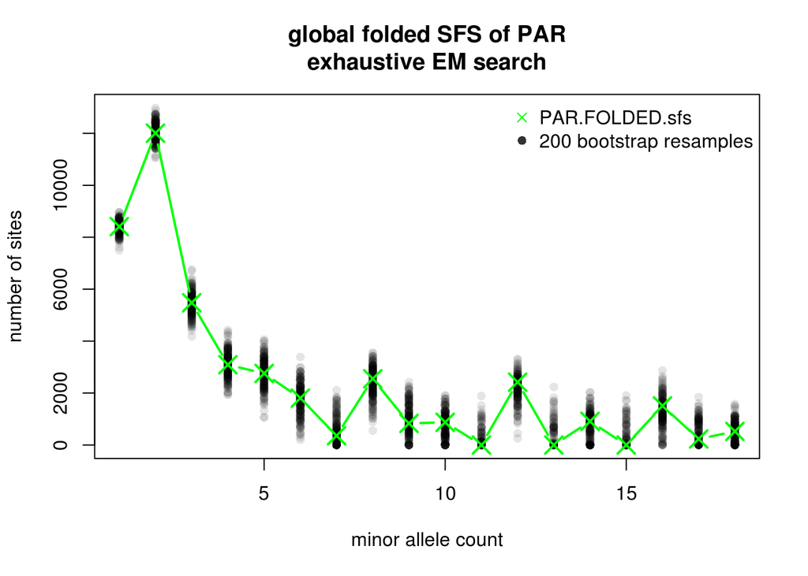

```r
matplot(1:18,
        t(par.sfs.boot.exh[2:ncol(par.sfs.boot.exh)]),
        #type="l",
        #lty=1,
        pch=16,
        col=gray(0, alpha=.1),
        ylab="number of sites",
        xlab="minor allele count",
        main="global folded SFS of PAR\nexhaustive EM search"
        )
# adding the real sample ML estimate to the plot:
points(1:18, par.sfs, pch=4, cex=2, col="green", type="b", lwd=2)
#text(15, 6000, labels=paste(nrow(ery.SFS.repeated), " repetitions"))
legend("topright",
       legend=c("PAR.FOLDED.sfs", "200 bootstrap resamples"),
       pch=c(4,16),
       pt.cex=1,
       col=c("green", gray(.2, alpha=1)),
       bty="n"
       )
```

```r
names(ery.sfs.boot.exh) = as.character(0:18)
ery.sfs.boot.exh.CI95 = as.data.frame(t( apply(ery.sfs.boot.exh, 2, quantile, probs=c(0.25, 0.5, 0.975)) ))
#
names(par.sfs.boot.exh) = as.character(0:18)
par.sfs.boot.exh.CI95 = as.data.frame(t( apply(par.sfs.boot.exh, 2, quantile, probs=c(0.25, 0.5, 0.975)) ))
```

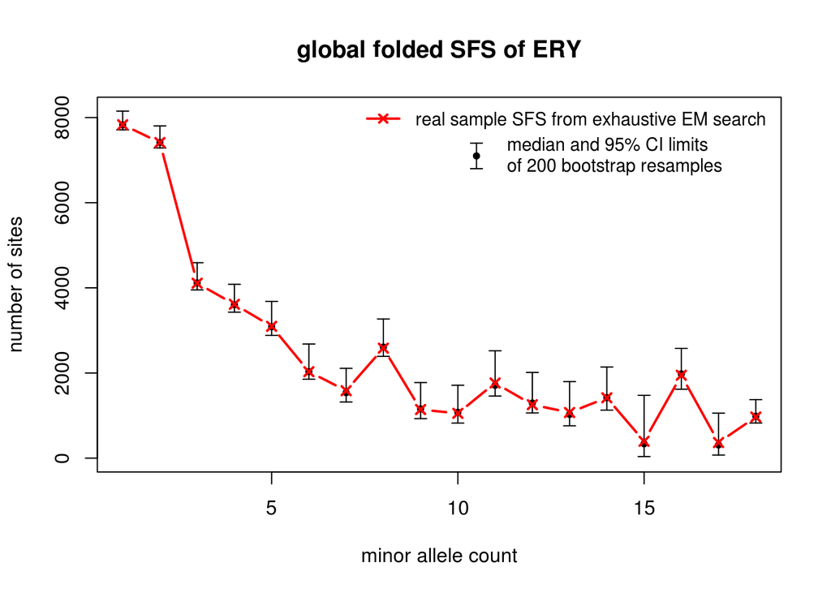

```r
plot(1:18,
     ery.sfs.boot.exh.CI95[2:19,2],
     ylim=c(0, max(ery.sfs.boot.exh.CI95[2:19,])),
     pch=20,
     xlab="minor allele count",
     ylab="number of sites",
     main="global folded SFS of ERY"
     )
arrows(1:18, ery.sfs.boot.exh.CI95[2:19,2],
       1:18, ery.sfs.boot.exh.CI95[2:19,3],
       angle=90,
       length=.05
       )
arrows(1:18, ery.sfs.boot.exh.CI95[2:19,2],
       1:18, ery.sfs.boot.exh.CI95[2:19,1],
       angle=90,
       length=.05
       )
points(1:18, ery.sfs, pch=4, cex=1, col="red", type="b", lwd=2)
legend("topright", legend="real sample SFS from exhaustive EM search", bty="n", col="red", pch=4, lwd=2, cex=.9)
#
points(10.5, 7100, pch=20)
arrows(10.5, 7100,
       10.5, 7400,
       angle=90,
       length=.05
       )
arrows(10.5, 7100,
       10.5, 6800,
       angle=90,
       length=.05
       )
#
text(11, 7000,
     labels="median and 95% CI limits\nof 200 bootstrap resamples",
     cex=.9, pos=4)
```

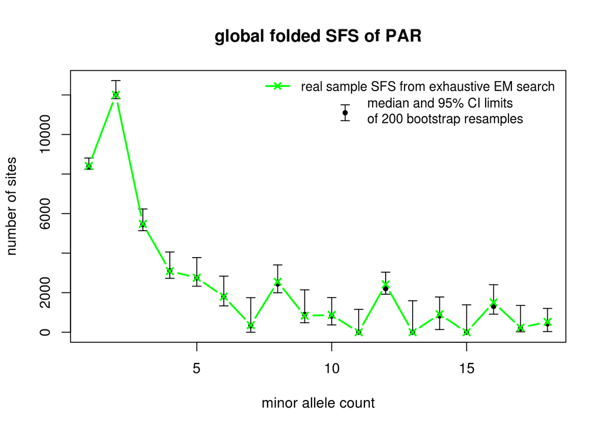

```r
plot(1:18,
     par.sfs.boot.exh.CI95[2:19,2],
     ylim=c(0, max(par.sfs.boot.exh.CI95[2:19,])),
     pch=20,
     xlab="minor allele count",
     ylab="number of sites",
     main="global folded SFS of PAR"
     )
arrows(1:18, par.sfs.boot.exh.CI95[2:19,2],
       1:18, par.sfs.boot.exh.CI95[2:19,3],
       angle=90,
       length=.05
       )
arrows(1:18, par.sfs.boot.exh.CI95[2:19,2],
       1:18, par.sfs.boot.exh.CI95[2:19,1],
       angle=90,
       length=.05
       )
points(1:18, par.sfs, pch=4, cex=1, col="green", type="b", lwd=2)
legend("topright", legend="real sample SFS from exhaustive EM search", bty="n", col="green", pch=4, lwd=2, cex=.9)
#
points(10.5, 11100, pch=20)
arrows(10.5, 11100,
       10.5, 11500,
       angle=90,
       length=.05
       )
arrows(10.5, 11100,
       10.5, 10700,
       angle=90,
       length=.05
       )
#
text(11, 11000,
     labels="median and 95% CI limits\nof 200 bootstrap resamples",
     cex=.9, pos=4)
```

The SFS’s estimated from the real samples (also with exhaustive EM search) match the medians of the frequency classes from bootstrap resampled sites very well for each population.

## Diversity Estimates

### S and $\pi$

```r
ery.sfs.boot = read.table("ERY/ERY.FOLDED.sfs.boot.exh", header=F)
dim(ery.sfs.boot)
```

```
## [1] 200  19
```

```r
# number of segregating sites:
S.ery.boot = apply( ery.sfs.boot, c(1), function(x) sum(x[2:length(x)]) )
quantile(S.ery.boot, probs=c(.025, .975))
```

```
##     2.5%    97.5%
## 43223.06 44075.84
```

```r
# average number of pairwise differences:
PI = function(sfs){
  n.half = 18
  n = 36
  1/(n*(n-1)/2) * sum( sapply(1:n.half, function(i) i*(n-i)*sfs[i]) )
}
pi.ery.boot = apply( ery.sfs.boot, c(1), function(x) PI( x[2:length(x)] ) )
head(pi.ery.boot)
```

```
## [1] 10620.32 10730.01 10640.83 10621.32 10712.62 10631.60
```

```r
quantile(pi.ery.boot, probs=c(.025, .975))
```

```
##     2.5%    97.5%
## 10560.85 10791.38
```

```r
par.sfs.boot = read.table("PAR/PAR.FOLDED.sfs.boot.exh", header=F)
# number of segregating sites:
S.par.boot = apply( par.sfs.boot, c(1), function(x) sum(x[2:length(x)]) )
quantile(S.par.boot, probs=c(.025, .975))
```

```
##     2.5%    97.5%
## 43265.34 44231.44
```

```r
# average number of pairwise differences:
pi.par.boot = apply( par.sfs.boot, c(1), function(x) PI( x[2:length(x)] ) )
head(pi.par.boot)
```

```
## [1] 8852.718 8790.278 8789.182 8804.604 8903.623 8896.976
```

```r
quantile(pi.par.boot, probs=c(.025, .975))
```

```
##     2.5%    97.5%
## 8759.915 8953.467
```

```r
ery.sfs = read.table("ERY/ERY.FOLDED.sfs", header=F)
ery.nSites = sum(ery.sfs)
S.ery = apply( ery.sfs, c(1), function(x) sum(x[2:length(x)]) )
pi.ery = apply( ery.sfs, c(1), function(x) PI( x[2:length(x)] ) )
#
par.sfs = read.table("PAR/PAR.FOLDED.sfs", header=F)
par.nSites = sum(par.sfs)
S.par = apply( par.sfs, c(1), function(x) sum(x[2:length(x)]) )
pi.par = apply( par.sfs, c(1), function(x) PI( x[2:length(x)] ) )
```

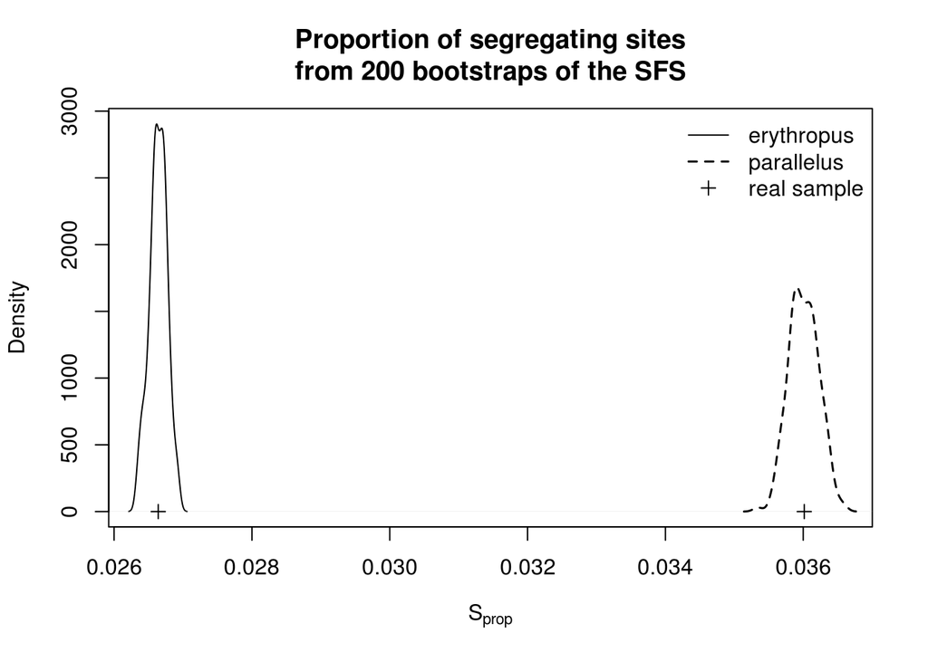

```r
plot(density(S.ery.boot/ery.nSites),
     xlab=expression(S[prop]),
     xlim=range(S.ery.boot/ery.nSites, S.par.boot/par.nSites),
     main="Proportion of segregating sites\nfrom 200 bootstraps of the SFS")
lines(density(S.par.boot/par.nSites), lty=2, lwd=1.5)
points(c(S.ery/ery.nSites, S.par/par.nSites), c(0, 0), pch=3)
legend("topright", legend=c("erythropus", "parallelus", "real sample"),
       lty=c(1, 2, NA), lwd=c(1, 1.5, NA), pch=c(NA, NA, 3), bty="n")
```

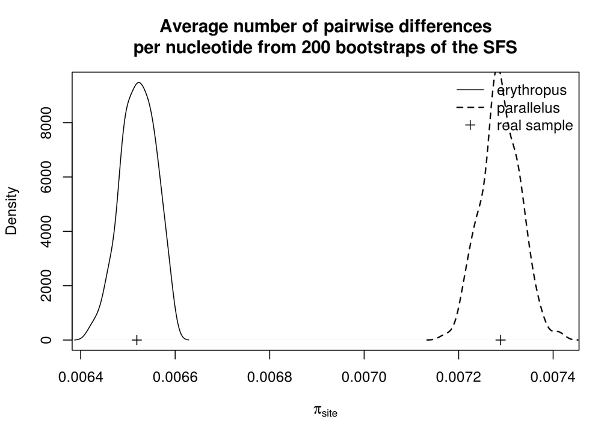

```r
plot(density(pi.ery.boot/ery.nSites),
     xlim=range(c(pi.ery.boot/ery.nSites, pi.par.boot/par.nSites)),
     xlab=expression(pi[site]),
     main="Average number of pairwise differences\nper nucleotide from 200 bootstraps of the SFS"
     )
lines(density(pi.par.boot/par.nSites), lty=2, lwd=1.5)
points(c(pi.ery/ery.nSites, pi.par/par.nSites), c(0, 0), pch=3)
legend("topright", legend=c("erythropus", "parallelus", "real sample"), lty=c(1, 2, NA),
       lwd=c(1, 1.5, NA), pch=c(NA, NA, 3), bty="n")
```

Both $S_{site}$ and $\pi_{site}$ are considerably higher in *parallelus* than in *erythropus*. If *parallelus* is derived from a Balkan refuge, I would expect it to have undergone a series of founder events. These should have reduced diversity, at least $\pi$, in *parallelus* more than in *erythropus* that comparitively would have had only a short distance to migrate from its glacial refuge. Subsequent population expansion would have allowed $S$ to recover quickly.

### Global Tajima’s D

```r
# 1. calculate constant (see p. 45 in Gillespie)
# ery
n = 36
a1 = sum(sapply(1:(n-1), function(x) x^(-1)))
a2 = sum(sapply(1:(n-1), function(x) x^(-2)))
b1 = (n+1)/(3*(n-1))
b2 = 2*(n^2+n+3)/(9*n*(n-1))
c1 = b1 - (1/a1)
c2 = b2 - (n+2)/(a1*n)+a2/a1^2
C = sqrt( c1/a1*S.ery + (c2/(a1^2+a2))*S.ery*(S.ery-1) )
( ery.TajimasD.global = (pi.ery - S.ery/a1)/C )
```

```
## [1] 0.0561255
```

```r
# 1. calculate constant (see p. 45 in Gillespie)
# par
n = 36
a1 = sum(sapply(1:(n-1), function(x) x^(-1)))
a2 = sum(sapply(1:(n-1), function(x) x^(-2)))
b1 = (n+1)/(3*(n-1))
b2 = 2*(n^2+n+3)/(9*n*(n-1))
c1 = b1 - (1/a1)
c2 = b2 - (n+2)/(a1*n)+a2/a1^2
C = sqrt( c1/a1*S.par + (c2/(a1^2+a2))*S.par*(S.par-1) )
( par.TajimasD.global = (pi.par - S.par/a1)/C )
```

```
## [1] -0.6142268
```

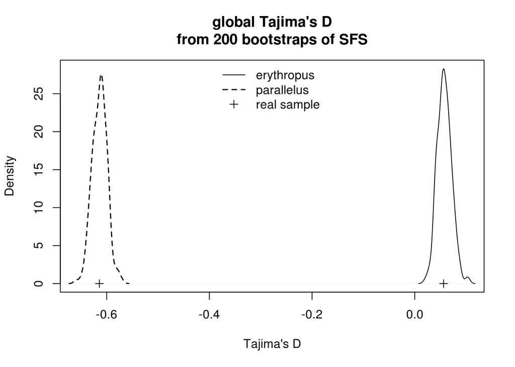

```r
C.boot = sqrt( c1/a1*S.ery.boot + (c2/(a1^2+a2))*S.ery.boot*(S.ery.boot-1) )
ery.TajimasD.global.boot = (pi.ery.boot - S.ery.boot/a1)/C.boot
#
C.boot = sqrt( c1/a1*S.par.boot + (c2/(a1^2+a2))*S.par.boot*(S.par.boot-1) )
par.TajimasD.global.boot = (pi.par.boot - S.par.boot/a1)/C.boot
#
plot(density(ery.TajimasD.global.boot),
     xlim=range(ery.TajimasD.global.boot, par.TajimasD.global.boot),
     type="l",
     xlab="Tajima's D",
     main="global Tajima's D\nfrom 200 bootstraps of SFS"
     )
lines(density(par.TajimasD.global.boot), lty=2, lwd=1.5)
points(c(ery.TajimasD.global, par.TajimasD.global), c(0, 0), pch=3)
legend("top", legend=c("erythropus", "parallelus", "real sample"), lty=c(1, 2, NA),
       lwd=c(1, 1.5, NA), pch=c(NA, NA, 3), bty="n")
```

### Tajima’s D per contig

I have estimated per-contig Tajima’s D values with the empirical Bayes method described in Korneliussen2013. This uses the ML global SFS as prior for posterior SAF’s that are summed across sites to get the SFS for a region/contig. From this local SFS, local $S$, $\pi$ and Tajima’s D can be derived.

```r
pp = pipe("cut -f 2,4,5,9,14 /data3/claudius/Big_Data/ANGSD/THETASTAT/ERY/ERY.thetas.gz.pestPG",
          open="r"
          )
thetas.ery = read.table(pp, header=TRUE)
close(pp)
head(thetas.ery)
```

```
##         Chr       tW       tP    Tajima nSites
## 1 Contig_16 0.016324 0.004369 -0.361801     39
## 2 Contig_17 0.013699 0.003794 -0.327604     39
## 3 Contig_40 0.747833 0.698273 -0.175456     39
## 4 Contig_46 0.739295 1.049866  1.108267     39
## 5 Contig_53 0.017697 0.005133 -0.364992     39
## 6 Contig_99 0.273420 0.152248 -0.814871     35
```

```r
nrow(thetas.ery)
```

```
## [1] 32706
```

```r
#
pp = pipe("cut -f 2,4,5,9,14 /data3/claudius/Big_Data/ANGSD/THETASTAT/PAR/PAR.thetas.gz.pestPG",
          open="r"
          )
thetas.par = read.table(pp, header=TRUE)
close(pp)
head(thetas.par)
```

```
##          Chr       tW       tP    Tajima nSites
## 1  Contig_40 0.726954 0.247784 -1.729843     39
## 2  Contig_53 0.509242 0.617952  0.497656     39
## 3 Contig_179 0.470037 0.309372 -0.774425     43
## 4 Contig_181 0.321413 0.229371 -0.561896     36
## 5 Contig_195 0.749432 0.427895 -1.136666     39
## 6 Contig_219 0.944613 0.380629 -1.693624     39
```

```r
nrow(thetas.par)
```

```
## [1] 24336
```

```r
save(thetas.ery, thetas.par, file="thetas.RData")
```

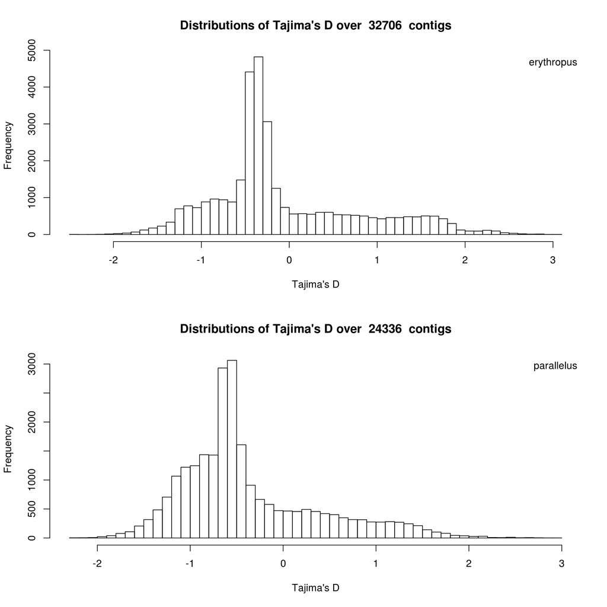

```r
par(mfrow=c(2,1))
hist(thetas.ery$Tajima, breaks=40,
     main=paste("Distributions of Tajima's D over ", nrow(thetas.ery), " contigs"),
     xlab="Tajima's D"
     )
legend("topright", legend=c("erythropus"), bty="n")
hist(thetas.par$Tajima, breaks=40,
     main=paste("Distributions of Tajima's D over ", nrow(thetas.par), " contigs"),
     xlab="Tajima's D"
     )
legend("topright", legend=c("parallelus"), bty="n")
```